# Electricity Consumption and Renewable Energy Generation in Colorado

### Split train-test dataset

```
## 'data.frame':    368 obs. of  23 variables:
##  $ residentialRevenue     : int  71325 59866 60470 56481 54336 53135 55149 53829 51810 52246 ...
##  $ residentialSales       : int  1046805 925315 896254 799898 747651 721876 761436 733880 733318 729053 ...
##  $ residentialCustomers   : num  0 0 0 0 0 0 0 0 0 0 ...
##  $ residentialPrice       : num  6.81 6.47 6.75 7.06 7.27 7.36 7.24 7.33 7.07 7.17 ...
##  $ commercialRevenue      : int  65130 55779 59278 60614 62544 66437 70513 69583 65979 65061 ...
##  $ commercialSales        : int  1158963 1090136 1085215 1049917 1049234 1106374 1230847 1196183 1193378 1132344 ...
##  $ commercialCustomers    : num  0 0 0 0 0 0 0 0 0 0 ...
##  $ commercialPrice        : num  5.62 5.12 5.46 5.77 5.96 6 5.73 5.82 5.53 5.75 ...
##  $ industrialRevenue      : int  24488 21595 22824 23821 24339 24763 26588 26028 24981 25999 ...
##  $ industrialSales        : int  545387 526880 527831 526066 527010 527276 579466 565798 566547 579756 ...
##  $ industrialCustomers    : num  0 0 0 0 0 0 0 0 0 0 ...
##  $ industrialPrice        : num  4.49 4.1 4.32 4.53 4.62 4.7 4.59 4.6 4.41 4.48 ...
##  $ transportationRevenue  : num  0 0 0 0 0 0 0 0 0 0 ...
##  $ transportationSales    : num  0 0 0 0 0 0 0 0 0 0 ...
##  $ transportationCustomers: num  0 0 0 0 0 0 0 0 0 0 ...
##  $ transportationPrice    : num  0 0 0 0 0 0 0 0 0 0 ...
##  $ otherRevenue           : num  4054 3900 3961 3913 4581 ...
##  $ otherSales             : num  58780 59198 54967 50106 55081 ...
##  $ otherPrice             : num  6.9 6.59 7.21 7.81 8.32 9.5 8.12 5.85 5.7 7.86 ...
##  $ totalRevenue           : int  164996 141140 146533 144829 145801 150583 163676 155996 148622 147684 ...
##  $ totalSales             : int  2809935 2601529 2564267 2425988 2378977 2421282 2712421 2607900 2595878 2496892 ...
##  $ totalCustomers         : num  0 0 0 0 0 0 0 0 0 0 ...
##  $ totalPrice             : num  5.87 5.43 5.71 5.97 6.13 6.22 6.03 5.98 5.73 5.91 ...
```

## Model fitting

We fitted different machine learning models with total electricity sales as a response variable and made predictions.

### Multiple linear regression

```
##
## Call:
## lm(formula = .outcome ~ ., data = dat)
##
## Residuals:
##      Min       1Q   Median       3Q      Max
## -1.28484 -0.12692  0.01091  0.14208  1.27401
##
## Coefficients: (1 not defined because of singularities)
##                           Estimate Std. Error    t value Pr(>|t|)
## (Intercept)              2.117e-01  2.284e+00      0.093   0.9262
## residentialRevenue       3.097e-02  5.239e-02      0.591   0.5550
## residentialSales         1.000e+00  1.566e-06 638684.892   <2e-16 ***
## residentialCustomers    -4.477e-06  2.406e-06     -1.861   0.0639 .
## residentialPrice         8.395e-01  9.835e-01      0.854   0.3941
## commercialRevenue        3.094e-02  5.239e-02      0.591   0.5553
## commercialSales          1.000e+00  1.913e-06 522874.965   <2e-16 ***
## commercialCustomers      2.775e-05  1.579e-05      1.757   0.0800 .
## commercialPrice          1.367e+00  1.033e+00      1.323   0.1871
## industrialRevenue        3.090e-02  5.239e-02      0.590   0.5558
## industrialSales          1.000e+00  2.207e-06 453060.095   <2e-16 ***
## industrialCustomers      1.969e-05  3.838e-05      0.513   0.6083
## industrialPrice          1.378e+00  9.324e-01      1.478   0.1406
## transportationRevenue    3.068e-02  5.244e-02      0.585   0.5590
## transportationSales      1.000e+00  1.998e-04   5006.032   <2e-16 ***
## transportationCustomers -2.851e-01  1.191e+00     -0.239   0.8111
## transportationPrice     -6.150e-02  7.600e-02     -0.809   0.4191
## otherRevenue             3.113e-02  5.240e-02      0.594   0.5529
## otherSales               1.000e+00  1.100e-05  90938.307   <2e-16 ***
## otherPrice              -1.114e-01  8.308e-02     -1.340   0.1813
## totalRevenue            -3.095e-02  5.239e-02     -0.591   0.5552
## totalCustomers                  NA         NA         NA       NA
## totalPrice              -3.244e+00  2.793e+00     -1.161   0.2465
## ---
## Signif. codes:  0 '***' 0.001 '**' 0.01 '*' 0.05 '.' 0.1 ' ' 1
##
## Residual standard error: 0.524 on 272 degrees of freedom
## Multiple R-squared:      1,  Adjusted R-squared:      1
## F-statistic: 2.881e+13 on 21 and 272 DF,  p-value: < 2.2e-16
```

### Decision Tree

```
## CART
##
## 294 samples
##  22 predictor
##
## No pre-processing
## Resampling: Cross-Validated (5 fold)
## Summary of sample sizes: 235, 235, 236, 235, 235
## Resampling results across tuning parameters:
##
##   cp          RMSE      Rsquared   MAE
##   0.07262643  289138.8  0.8546107  237341.7
##   0.12616616  399998.1  0.7227249  330940.4
##   0.69168734  556964.3  0.6629876  461579.7
##
## RMSE was used to select the optimal model using the smallest value.
## The final value used for the model was cp = 0.07262643.
```

### Random Forest

```
## Random Forest
##
## 294 samples
##  22 predictor
##
## No pre-processing
## Resampling: Cross-Validated (5 fold)
## Summary of sample sizes: 234, 235, 236, 236, 235
## Resampling results across tuning parameters:
##
##   mtry  RMSE       Rsquared   MAE
##    2    131221.87  0.9722230  97911.90
##   12     66706.54  0.9923153  50299.17
##   22     67329.15  0.9919648  50910.04
##
## RMSE was used to select the optimal model using the smallest value.
## The final value used for the model was mtry = 12.
```

### Support vector machine

```
## Support Vector Machines with Radial Basis Function Kernel
##
## 294 samples
##  22 predictor
##
## No pre-processing
## Resampling: Cross-Validated (5 fold)
## Summary of sample sizes: 235, 234, 235, 236, 236
## Resampling results across tuning parameters:
##
##   C     RMSE       Rsquared   MAE
##   0.25  138013.67  0.9710832  77450.79
##   0.50  101257.92  0.9832036  62378.70
##   1.00   78406.52  0.9899682  53656.12
##
## Tuning parameter 'sigma' was held constant at a value of 0.2068405
## RMSE was used to select the optimal model using the smallest value.
## The final values used for the model were sigma = 0.2068405 and C = 1.
```

### Model check

From the root mean square error (RMSE) of these four models, we can see that the multiple linear regression model performs best in predicting electricity sales, which may be related to the linear relationship between the response variable and the predictor variable.

```
## [1] "RMSE of Multiple linear regression： 0.509245703449566"
```

```
## [1] "RMSE of Decision Trees： 348140.414348679"
```

```
## [1] "RMSE of Random Forest： 69334.3925098738"
```

```
## [1] "RMSE of Support vector machine： 97473.7998019751"
```

### Ensemble

Now we train multiple models simultaneously, cross-validate them and calculate evaluation metrics that help us choose the best model.

```
##
## Call:
## summary.resamples(object = results)
##
## Models: glm, rf, rpart, svmRadial
## Number of resamples: 10
##
## MAE
##                   Min.      1st Qu.       Median         Mean      3rd Qu.
## glm       2.483054e-01 3.251156e-01 3.525566e-01 3.656808e-01 4.101310e-01
## rf        3.856633e+04 4.121489e+04 4.527360e+04 4.655648e+04 4.977156e+04
## rpart     1.831003e+05 2.199420e+05 2.771358e+05 2.597715e+05 2.865094e+05
## svmRadial 3.808238e+04 4.929526e+04 5.213941e+04 5.169144e+04 5.420214e+04
##                   Max. NA's
## glm       5.035633e-01    0
## rf        6.046319e+04    0
## rpart     3.249328e+05    0
## svmRadial 6.703784e+04    0
##
## RMSE
##                   Min.      1st Qu.       Median         Mean      3rd Qu.
## glm       3.916270e-01 5.098089e-01 5.432182e-01 5.564860e-01 6.173846e-01
## rf        4.757392e+04 5.409260e+04 5.896705e+04 6.142299e+04 6.762439e+04
## rpart     2.366738e+05 2.702184e+05 3.216412e+05 3.148162e+05 3.490270e+05
## svmRadial 4.643964e+04 6.920321e+04 7.091314e+04 7.586467e+04 7.871333e+04
##                   Max. NA's
## glm       6.927776e-01    0
## rf        8.299571e+04    0
## rpart     3.963666e+05    0
## svmRadial 1.098335e+05    0
##
## Rsquared
##                Min.   1st Qu.    Median      Mean   3rd Qu.      Max. NA's
## glm       1.0000000 1.0000000 1.0000000 1.0000000 1.0000000 1.0000000    0
## rf        0.9828249 0.9923234 0.9939790 0.9932573 0.9959403 0.9969025    0
## rpart     0.7574158 0.7968386 0.8217899 0.8321542 0.8772453 0.9089569    0
## svmRadial 0.9791394 0.9892371 0.9922436 0.9899597 0.9932365 0.9962272    0
```

From the Mean Absolute Error(MAE) and root mean square error (RMSE) in the model evaluation above we can conclude that the best performing model is multiple linear regression, followed by random forest and support vector machine, and the decision tree algorithm does not perform as well as it should in this problem.

# Renewable Energy Analysis

Next we need to analyze the annual renewable energy generation in Colorado since 1960. By analyzing this data, we can understand the use and trends of renewable energy in Colorado.

U.S. Energy Information Administration collects yearly Total Renewable Energy Production data of Colorada, and units are billion Bu.

From the time series plot, there is an obvious upward trend generally, so it seems not to be stationary. In order to do the following analysis and forcasts works. we need to do transformations.

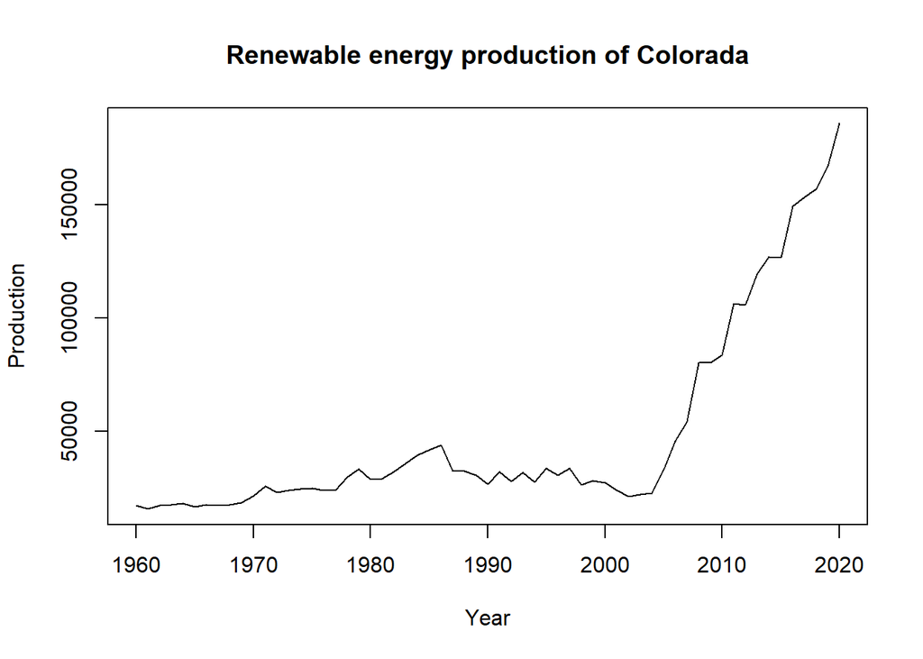

To eliminate the trend, we performed two differentials on the data. We take Dicky-Fuller (DF) Test, which is a type of unit root test that tests the null hypothesis that a time series has a unit root against the alternative hypothesis that it does not have a unit root. The results show that the p- value < 0.05, rejecting the original hypothesis and the data is stationary.

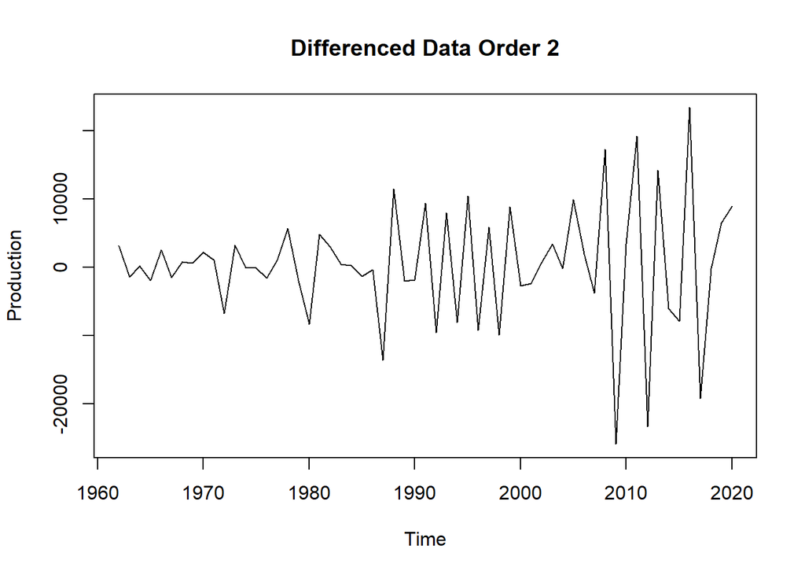

```
##
##  Augmented Dickey-Fuller Test
##
## data:  diff_ts
## Dickey-Fuller = -5.3715, Lag order = 3, p-value = 0.01
## alternative hypothesis: stationary
```

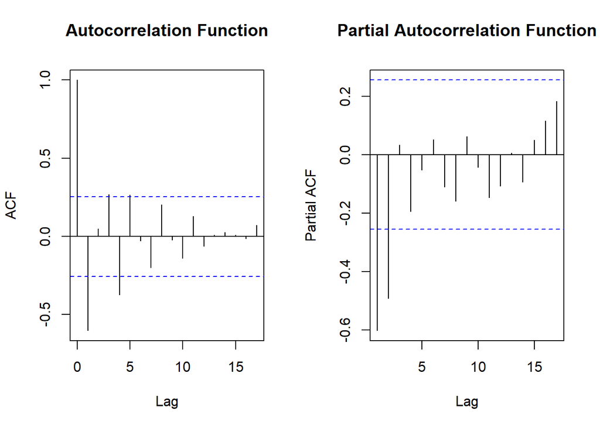

We apply auto.arima() function as a reference Since there are many fitting models, I chose the three most likely models based on the ACF and PACF plots. Through the results, we can see that the second model has the smallest AIC and BIC values, so I choose ARIMA(2,2,2) as my final model to do the following forecasts

```
## Series: diff_ts
## ARIMA(5,2,0)
##
## Coefficients:
##           ar1      ar2      ar3      ar4      ar5
##       -2.0837  -2.5361  -2.1173  -1.3151  -0.4785
## s.e.   0.1252   0.2693   0.3392   0.2685   0.1270
##
## sigma^2 = 79389077:  log likelihood = -599.39
## AIC=1210.78   AICc=1212.46   BIC=1223.03
##
## Training set error measures:
##                    ME     RMSE      MAE      MPE     MAPE      MASE       ACF1
## Training set 379.3758 8364.809 5881.161 37.64382 385.8945 0.5256636 -0.1802985
```

|  | Model | AIC | BIC |
| --- | --- | --- | --- |
| fit1 | fit1 | 1210.776 | 1223.034 |
| fit2 | fit2 | 1181.732 | 1191.948 |
| fit3 | fit3 | 1237.102 | 1243.231 |

### ARIMA Forecast

Through the picture we can see that the future energy production are in a clear upward trend in the following seven years.

```
##      Point Forecast    Lo 80    Hi 80    Lo 95    Hi 95
## 2021       194376.4 186827.3 201925.4 182831.1 205921.7
## 2022       205369.0 194665.1 216072.9 188998.8 221739.3
## 2023       218500.6 204119.2 232881.9 196506.2 240494.9
## 2024       228119.3 208705.2 247533.4 198427.9 257810.6
## 2025       240417.6 216438.2 264397.0 203744.3 277090.9
## 2026       251545.6 222173.7 280917.6 206625.1 296466.1
## 2027       262652.8 227656.7 297649.0 209130.8 316174.8
```

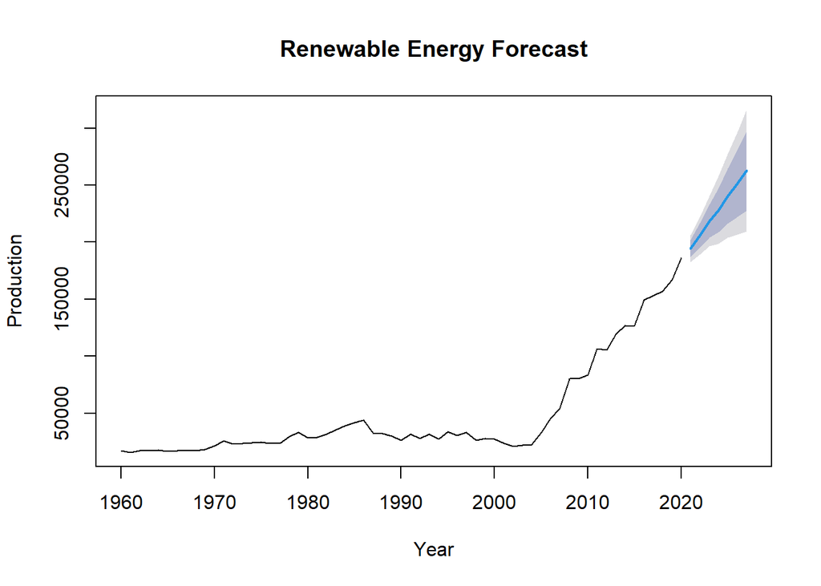

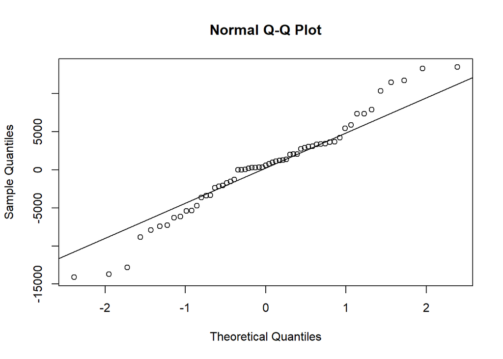

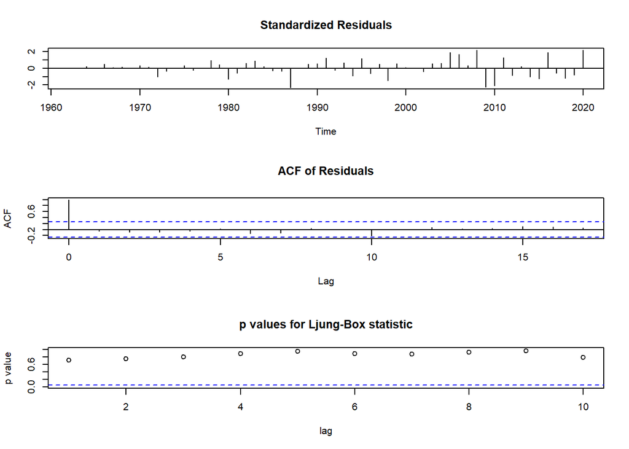

We found that one of the ten largest plants in Colorado by electricity generation is wind power and is ranked 7th, indicating that wind power is starting to become important in Colorado. Nevertheless, coal is still the main source of energy for power generation, so we focus our analysis below on wind and coal consumption.

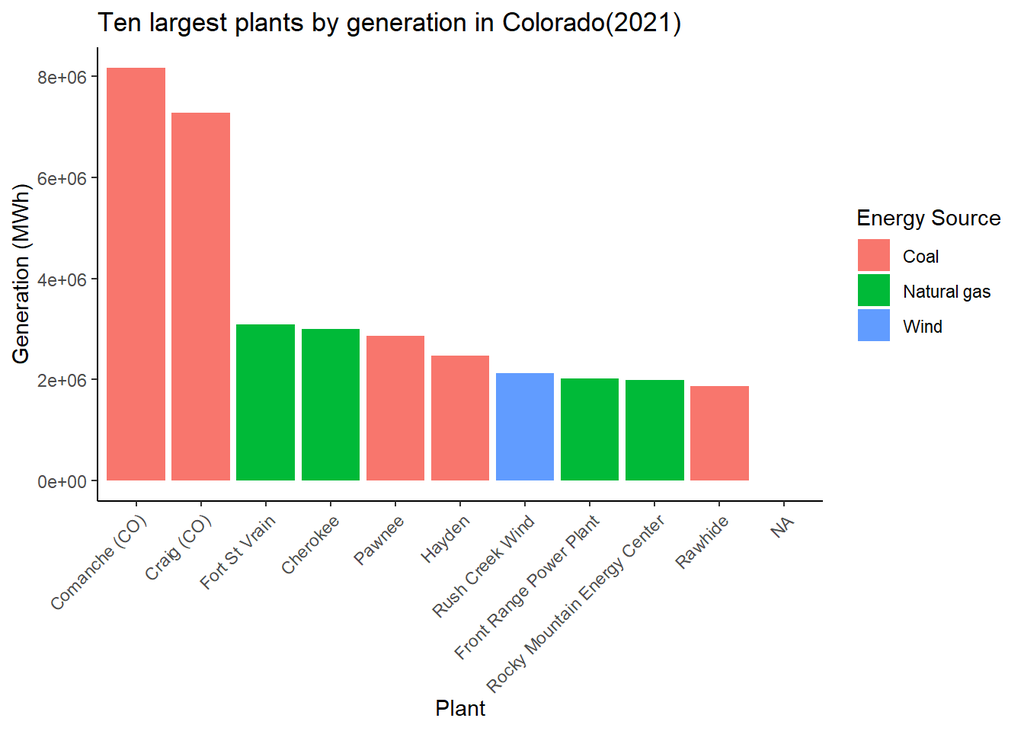

## Wind consumption

We also make forecasts of wind energy total consumption. The units are billion Bu.

This is the time series model of wind energy total consumption for the available years.

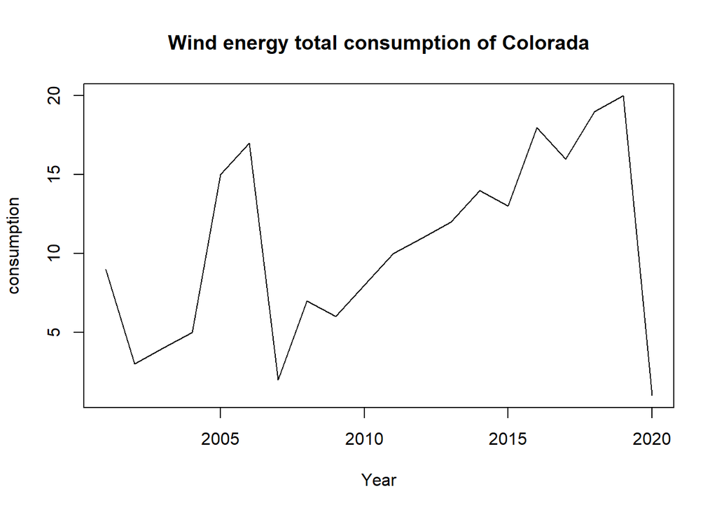

### Holt-Winters Forecast

```
##      Point Forecast     Lo 80     Hi 80      Lo 95    Hi 95
## 2021      -1.299012 -11.14852  8.550501  -16.36254 13.76452
## 2022      -3.986482 -19.10487 11.131904  -27.10806 19.13509
## 2023      -6.673951 -26.79747 13.449563  -37.45021 24.10231
## 2024      -9.361421 -34.51589 15.793045  -47.83186 29.10901
## 2025     -12.048891 -42.35571 18.257923  -58.39916 34.30138
## 2026     -14.736361 -50.35640 20.883673  -69.21250 39.73978
## 2027     -17.423831 -58.53541 23.687751  -80.29857 45.45091
## 2028     -20.111301 -66.90011 26.677506  -91.66861 51.44600
## 2029     -22.798771 -75.45275 29.855205 -103.32608 57.72854
## 2030     -25.486241 -84.19290 33.220419 -115.27033 64.29785
```

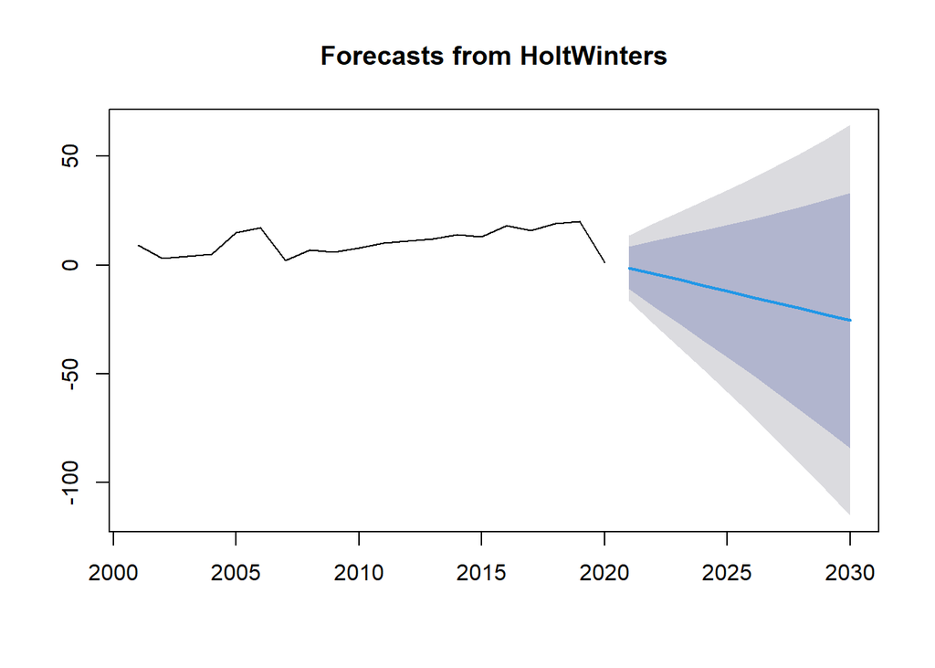

## coal(Non-renewable energy) consumption

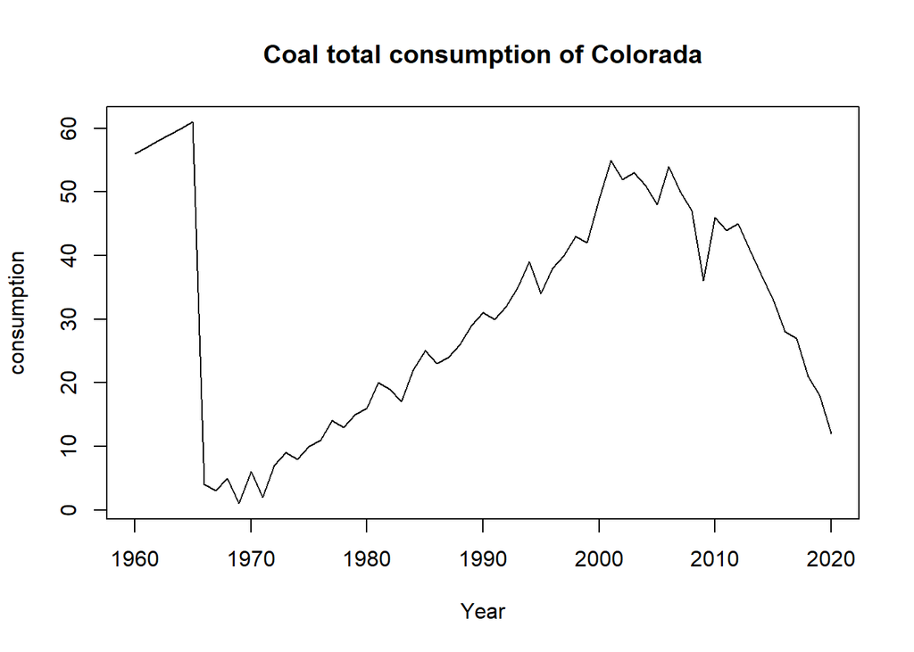

### Holt-Winters Forecast

Coal consumption is basically flat, with no upward trend in the future

```
##      Point Forecast      Lo 80    Hi 80      Lo 95    Hi 95
## 2021       12.11208   1.459409 22.76475  -4.179773 28.40393
## 2022       12.11208  -2.814353 27.03851 -10.715928 34.94008
## 2023       12.11208  -6.112008 30.33616 -15.759257 39.98341
## 2024       12.11208  -8.898307 33.12246 -20.020534 44.24469
## 2025       12.11208 -11.356098 35.58025 -23.779400 48.00356
## 2026       12.11208 -13.579832 37.80399 -27.180308 51.40446
## 2027       12.11208 -15.625861 39.85002 -30.309438 54.53359
## 2028       12.11208 -17.531002 41.75516 -33.223101 57.44726
## 2029       12.11208 -19.320885 43.54504 -35.960491 60.18465
## 2030       12.11208 -21.014198 45.23835 -38.550190 62.77435
```

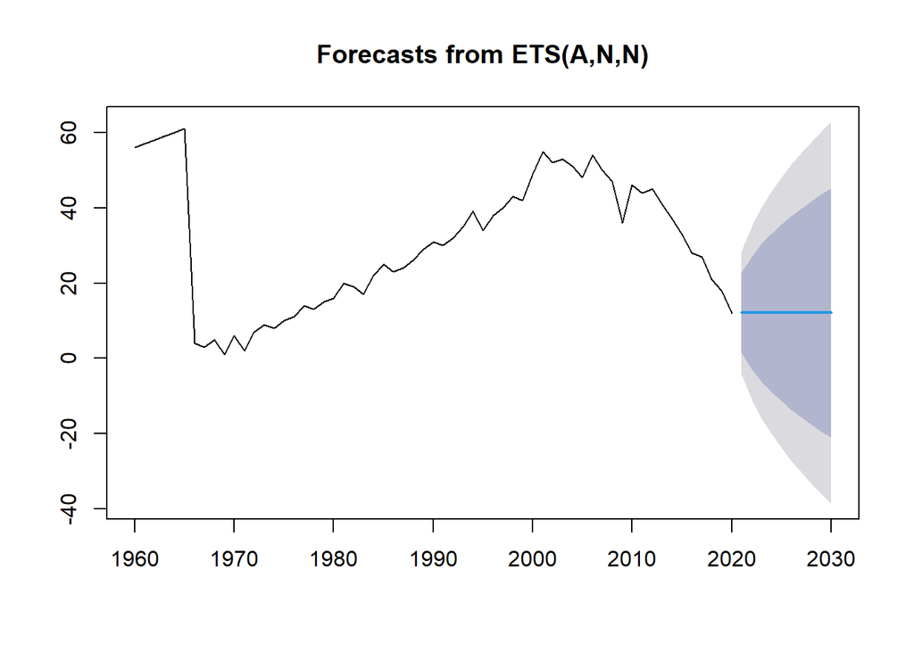

# Conclusion

By analyzing the data, we can find that Colorado’s electricity market shows a trend of transitioning from traditional to renewable energy sources as the use of renewable energy increases. The development of renewable energy sources not only has a positive impact on the environment and climate change, but also brings good opportunities for economic and employment development in the state.

In summary, by analyzing the revenue and pricing of monthly electricity consumption in Colorado since 1990 versus annual renewable energy consumption since 1960, we can better understand the development and future trends of the electricity market and provide data to support better electricity planning and decision making by government and energy companies.